## * CALISTA MAIN SCRIPT *

Example 4.Human embryonic stem cell differentiation into endodermal cells (Example_4_CHU_scRNA_seq.m script in the main folder of CALISTA)

Analysis of RNA-seq data in Chu et al., [Single-cell RNA-seq reveals novel regulators of human embryonic stem cell differentiation to definitive endoderm, Genome Biol. 17, 173 (2016)](https://genomebiology.biomedcentral.com/articles/10.1186/s13059-016-1033-x).

**Please unzip the file “4-CHU__data_type_4_format_data_2_clusters_4.csv.zip” in EXAMPLES/CHU/ before running CALISTA**

We begin with changing the current directory in MATLAB to the CALISTA folder. Type 'cd' in the command window then copy and paste the current path in 'curr_path':

```matlab
clc
clear all
close all

% Add path for CALISTA folder:
% mfilename=matlab.desktop.editor.getActiveFilename;
% curr_path=fileparts(which(mfilename));

% In windows
 curr_path='C:\Users\npgao\polybox\CALISTA-MATLAB_1.2.2';
% In MacOS
%curr_path='/Users/nan/polybox/CALISTA-MATLAB_1.2.2';

cd(curr_path);
addpath(genpath(curr_path))
warning ('off','all');
```

## * 1-Data Import and Preprocessing *

Type 'help import_data' in the command window for more information

Run the following section and import Chu dataset (available in the subfolder EXAMPLES/CHU).

```matlab
%% *** 1-Data Import and Preprocessing ***
%
% Type 'help import_data' for more information
%
% Specify pre-processing settings
INPUTS.data_type=4;% scRNA-seq data  (Expression values - e.g TPM or RPKM)
INPUTS.format_data=2; % Rows= genes and Columns= cells with time/stage info in the first row
INPUTS.zeros_genes=0.9;% Remove genes with > 90% of zeros
INPUTS.top_genes=70;% Retain only top 70 genes (10% of num of cells)
INPUTS.plot=0; % Do not display additional plots
%
% Specify single-cell clustering settings
INPUTS.optimize=1; % Find the optimal number of clusters
%
% Upload and pre-process data
[DATA,INPUTS] = import_data(INPUTS);
```

**** Please upload normalized data. File formats accepted: .txt , .xlxs , .csv, .mat, .loom **** Filtering genes by number of cells... Filtering cells by number of genes... % of zeros in the data 34.32 Selecting most variable genes... Normalizing the data... Finishing setup of the CALISTA data structure... DONE.

## * 2-SINGLE-CELL CLUSTERING *

Type 'help CALISTA_clustering_main' in the command window for more information.

NOTE: CALISTA automatically returns the optimal number of clusters based on the MAXIMUM eigengap value. However, the user might choose the number of clusters to adopt based on the FIRST eigengap.

```matlab
[Results, DATA, INPUTS]=CALISTA_clustering_main(DATA,INPUTS);
```

Detecting the optimal number of clusters with Eigengap heuristics... CALISTA_clustering is running... Progress: .................................................. |||||||||||||||||||||||||||||||||||||||||||||||||| Constructing consensus matrix... Elapsed time is 0.117708 seconds.

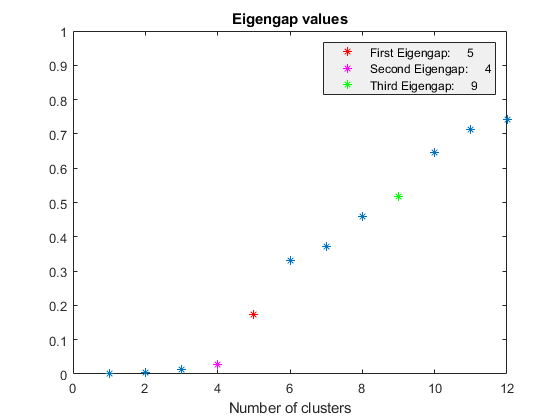

CALISTA_clustering is running... Progress: .................................................. |||||||||||||||||||||||||||||||||||||||||||||||||| Performing clustering based on consensus matrix... Constructing consensus matrix... Kmedois... Elapsed time is 3.855656 seconds. Plotting...

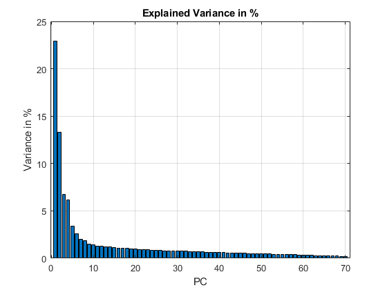

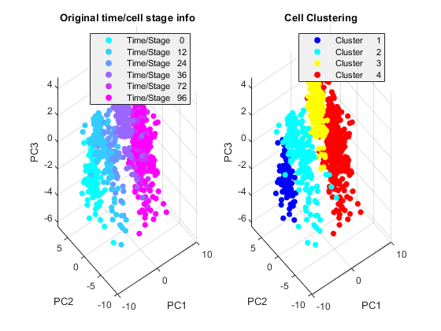

Elapsed time is 8.132057 seconds. DONE.

If desired, users can remove cells from specific clusters from further analysis. In this example, we do not want to remove any clusters. Hence, we enter 0 (no cluster removal) and then 1 to proceed with lineage inference:

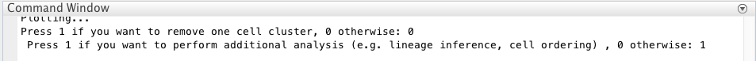

```matlab
%  Cluster removal (if desired)
cluster_cut=input('Press 1 if you want to remove cell cluster(s). Press 0 otherwise: ');

if cluster_cut==1

   which_cut=input('Enter cluster index for removal (e.g 1 or [5 3]): ');
   cells_2_cut2=find(ismember(Results.final_groups,which_cut)==1);
   cells_2_cut2=DATA.cut_sort.abs_indices(cells_2_cut2);
   csvwrite('Cells_2_remove',cells_2_cut2)
   RESULTS.cluster_cut = 1;
   fprintf('Cell''s indices to remove are saved in "Cells_2_remove.csv". Please run MAIN script again \n')
   return
end

Proceed=input(' Press 1 if you want to perform additional analysis (e.g. lineage inference, cell ordering) , 0 otherwise: ');
if ~Proceed
    return
end
```

## * 3-RECONSTRUCTION OF LINEAGE PROGRESSION *

Type 'help CALISTA_transition_main' in the command window for more information.

During the lineage inference step, CALISTA automatically generates and displays a lineage graph, obtained by adding an edge between two clusters in increasing cluster distances, until all clusters are connected to at least one other cluster. Subsequently, users can manually add or remove one edge at time based on the cluster distances.

ATTENTION:

- to add an edge (press “p”), remove an edge (press “m”) or finalize the lineage progression graph (press “enter”), the MATLAB figure of the graph must appear in foreground without any modification (e.g., zooming, rotation). Note that the addition/removal of the edges are performed according to increasing/decreasing order of cluster distance.
- the final graph must be connected (i.e. there exists a path from any node/cluster to any other node/cluster in the graph), otherwise a warning will be returned.

Here, we do not need to remove any spurious edges, and hence we enter 0 upon queried:

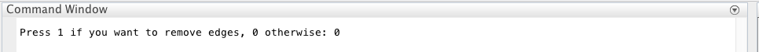

```matlab
[Results]=CALISTA_transition_main(DATA,INPUTS,Results);
```

CALISTA_transition is running...

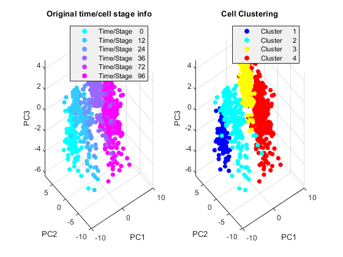

3 edge(s) have been added and the graph is connected. If you want to add another edge press "p" If you want to remove an edge press "m" If you want to continue with the next step press "enter" (Please make sure that figure 101 is in the foreground and no additional tools are selected (e.g. zooming, rotation, data cursor etc.)) ----------------------------------------------

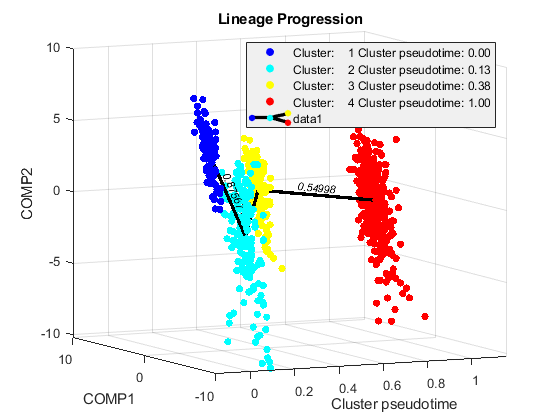

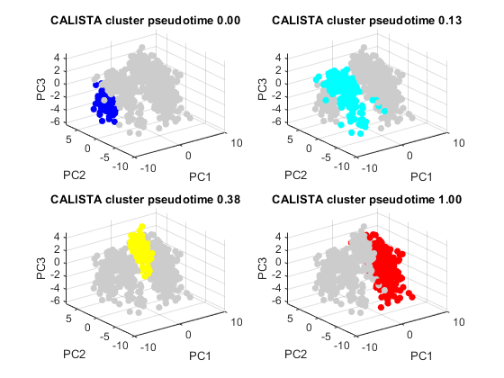

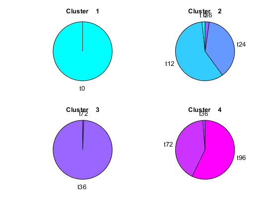

Plotting mean gene expressions...

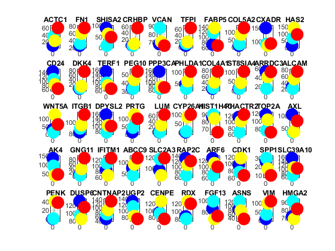

DONE.

```matlab
% % Save 3D video
% figure(100)
% % daspect([2,2,0.3]);
% OptionZ.FrameRate=20;OptionZ.Duration=20.5;OptionZ.Periodic=true;
% CaptureFigVid([-20,10;-110,10;-190,80;-290,10;-380,10], 'CALISTA_lineage_3Dvideo',OptionZ)
```

## * 4-DETERMINATION OF TRANSITION GENES *

Type 'help CALISTA_transition_genes_main' in the command window for more information.

After reconstructing the lineage progression, we identify the key transition genes for any two connected clusters in the graph, based on the gene-wise likelihood difference between having the cells separately as two clusters and together as a single cluster. Larger differences in the gene-wise likelihood point to more informative genes. The transition genes are selected as those whose gene-wise likelihood differences make up to more than a certain percentage of the cumulative sum of the likelihood differences of all genes – set by INPUTS.thr_transition_genes.

```matlab
[Results]=CALISTA_transition_genes_main(DATA,INPUTS,Results);
```

CALISTA_transition_genes is running... DONE.

## * 5-PSEUDOTEMPORAL ORDERING OF CELLS *

Type 'help CALISTA_ordering_main' in the command window for more information.

For pseudotemporal ordering of cells, CALISTA performs maximum likelihood optimization for each cell using a linear interpolation of the cell likelihoods between any two connected clusters. The pseudotimes of the cells are computed by linear interpolation of the cluster pseudotimes, and correspond to the maximum point of the likelihood optimization above. Cells are subsequently assigned to the edges in the lineage progression graph. The following screenshot gives the results of this cell-to-edge assignment.

```matlab
[Results]=CALISTA_ordering_main_2(DATA,INPUTS,Results);
```

CALISTA_ordering is running...

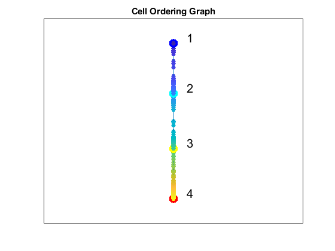

Waiting for plots...

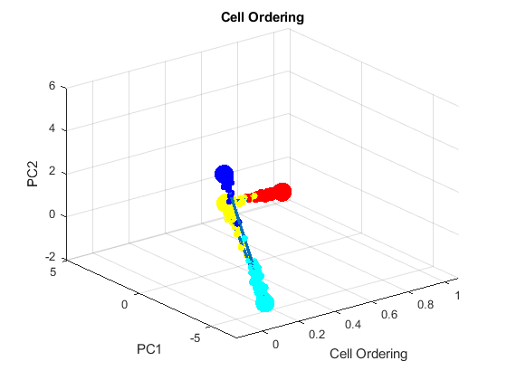

DONE.

```matlab
% [Results_transition_genes]=CALISTA_ordering_main_2_transition_genes(DATA,INPUTS,Results);
```